# Customizing an MCMC

NIMBLE ENAR webinar module

NIMBLE Development Team

# The litters model

Here’s the graph of the litters model.

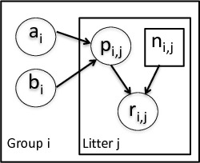

Here we set up the litters model.

```r
littersCode <- nimbleCode({
  for (i in 1:G) {
     for (j in 1:N) {
        # likelihood (data model)
        r[i,j] ~ dbin(p[i,j], n[i,j])
    # latent process (random effects)
        p[i,j] ~ dbeta(a[i], b[i])
     }
     # prior for hyperparameters
     a[i] ~ dgamma(1, .001)
     b[i] ~ dgamma(1, .001)
   }
})
```

```r
G <- 2
N <- 16
n <- matrix(c(13, 12, 12, 11, 9, 10,
              9, 9, 8, 11, 8, 10, 13, 10, 12, 9, 10, 9, 10, 5, 9, 9, 13,
              7, 5, 10, 7, 6, 10, 10, 10, 7), nrow = 2)
r <- matrix(c(13, 12, 12, 11, 9, 10, 9, 9, 8, 10, 8, 9,
     12, 9, 11, 8, 9, 8, 9, 4, 8, 7, 11, 4, 4, 5, 5, 3, 7, 3, 7, 0),
     nrow = 2)

littersConsts <- list(G = G, N = N, n = n)
littersData <- list(r = r)
littersInits <- list( a = c(2, 2), b=c(2, 2) )

littersModel <- nimbleModel(littersCode,
          data = littersData, constants = littersConsts, inits = littersInits)
```

```
## defining model...
```

```
## building model...
```

```
## setting data and initial values...
```

```
## running calculate on model (any error reports that follow may simply reflect missing values in model variables) ...
## checking model sizes and dimensions... This model is not fully initialized. This is not an error. To see which variables are not initialized, use model$initializeInfo(). For more information on model initialization, see help(modelInitialization).
## model building finished.
```

```r
cLittersModel <- compileNimble(littersModel)
```

```
## compiling... this may take a minute. Use 'showCompilerOutput = TRUE' to see C++ compiler details.
```

```
## compilation finished.
```

# NIMBLE’s default MCMC

Here are the results from running NIMBLE’s default MCMC:

```r
littersConf <- configureMCMC(littersModel, monitors = c('a', 'b', 'p'))
littersMCMC <- buildMCMC(littersConf)
cLittersMCMC <- compileNimble(littersMCMC, project = littersModel)
```

```
## compiling... this may take a minute. Use 'showCompilerOutput = TRUE' to see C++ compiler details.
```

```
## compilation finished.
```

```r
niter <- 5000
nburn <- 1000
set.seed(1)
samples <- runMCMC(cLittersMCMC, niter = niter, nburnin = nburn,
        inits = littersInits, nchains = 1, samplesAsCodaMCMC = TRUE)
```

```
## running chain 1...
```

```
## |-------------|-------------|-------------|-------------|
## |-------------------------------------------------------|
```

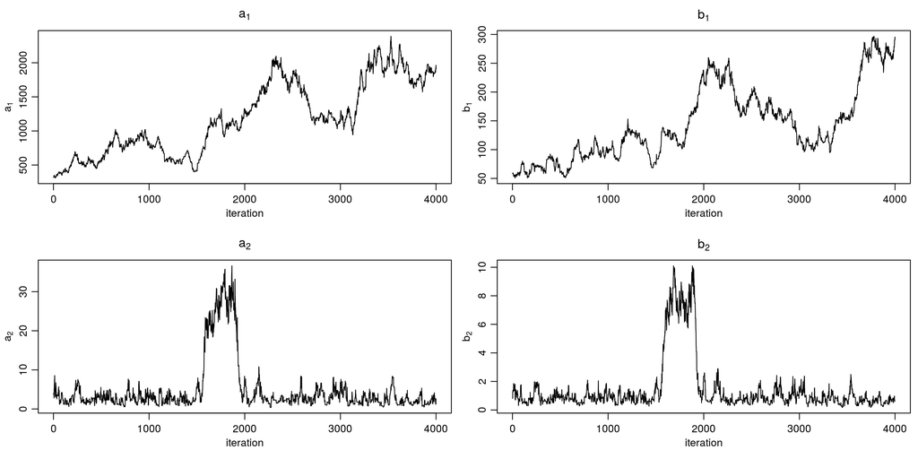

```r
makePlot <- function(smp) {
    par(mfrow = c(2, 2), mai = c(.6, .5, .4, .1), mgp = c(1.8, 0.7, 0))
    ts.plot(smp[ , 'a[1]'], xlab = 'iteration',
        ylab = expression(a[1]), main = expression(a[1]))
    ts.plot(smp[ , 'b[1]'], xlab = 'iteration',
        ylab = expression(b[1]), main = expression(b[1]))
    ts.plot(smp[ , 'a[2]'], xlab = 'iteration',
        ylab = expression(a[2]), main = expression(a[2]))
    ts.plot(smp[ , 'b[2]'], xlab = 'iteration',
        ylab = expression(b[2]), main = expression(b[2]))
}

makePlot(samples)
```

# Customizing samplers

As those who’ve worked with MCMC before know, MCMC is a family of algorithms and there are many ways to run an MCMC for any given model, including the choice of the kind of sampler used for each parameter in the model.

One of NIMBLE’s most important features is that users can easily modify the MCMC algorithm used for their model. The easiest thing to do is to start with NIMBLE’s default MCMC and then make modifications.

```r
littersConf$printSamplers()
```

```
## [1]  RW sampler: a[1]
## [2]  RW sampler: a[2]
## [3]  RW sampler: b[1]
## [4]  RW sampler: b[2]
## [5]  conjugate_dbeta_dbin sampler: p[1, 1]
## [6]  conjugate_dbeta_dbin sampler: p[1, 2]
## [7]  conjugate_dbeta_dbin sampler: p[1, 3]
## [8]  conjugate_dbeta_dbin sampler: p[1, 4]
## [9]  conjugate_dbeta_dbin sampler: p[1, 5]
## [10] conjugate_dbeta_dbin sampler: p[1, 6]
## [11] conjugate_dbeta_dbin sampler: p[1, 7]
## [12] conjugate_dbeta_dbin sampler: p[1, 8]
## [13] conjugate_dbeta_dbin sampler: p[1, 9]
## [14] conjugate_dbeta_dbin sampler: p[1, 10]
## [15] conjugate_dbeta_dbin sampler: p[1, 11]
```

[output cut: 21 more lines]

```r
hypers <- c('a[1]', 'b[1]', 'a[2]', 'b[2]')
for(h in hypers) {
      littersConf$removeSamplers(h)
      littersConf$addSampler(target = h, type = 'slice')
}
littersConf$printSamplers()
```

```
## [1]  conjugate_dbeta_dbin sampler: p[1, 1]
## [2]  conjugate_dbeta_dbin sampler: p[1, 2]
## [3]  conjugate_dbeta_dbin sampler: p[1, 3]
## [4]  conjugate_dbeta_dbin sampler: p[1, 4]
## [5]  conjugate_dbeta_dbin sampler: p[1, 5]
## [6]  conjugate_dbeta_dbin sampler: p[1, 6]
## [7]  conjugate_dbeta_dbin sampler: p[1, 7]
## [8]  conjugate_dbeta_dbin sampler: p[1, 8]
## [9]  conjugate_dbeta_dbin sampler: p[1, 9]
## [10] conjugate_dbeta_dbin sampler: p[1, 10]
## [11] conjugate_dbeta_dbin sampler: p[1, 11]
## [12] conjugate_dbeta_dbin sampler: p[1, 12]
## [13] conjugate_dbeta_dbin sampler: p[1, 13]
## [14] conjugate_dbeta_dbin sampler: p[1, 14]
## [15] conjugate_dbeta_dbin sampler: p[1, 15]
```

[output cut: 21 more lines]

```r
littersMCMC <- buildMCMC(littersConf)
## we need 'resetFunctions' because we are rebuilding the MCMC for an existing model
cLittersMCMC <- compileNimble(littersMCMC, project = littersModel, resetFunctions = TRUE)
```

```
## compiling... this may take a minute. Use 'showCompilerOutput = TRUE' to see C++ compiler details.
```

```
## compilation finished.
```

```r
set.seed(1)
samplesSlice <- runMCMC(cLittersMCMC, niter = niter, nburnin = nburn,
             inits = littersInits, nchains = 1, samplesAsCodaMCMC = TRUE)
```

```
## running chain 1...
```

```
## |-------------|-------------|-------------|-------------|
## |-------------------------------------------------------|
```

# Customizing samplers: Initial results

Caveat: the real question is the effective sample size per unit of computation time, but we don’t assess that here.

```r
library(coda, warn.conflicts = FALSE)
effectiveSize(samplesSlice)
```

```
##        a[1]        a[2]        b[1]        b[2]     p[1, 1]     p[2, 1]
##    5.393745   32.451333    5.478835   34.484120   38.329445  527.251563
##     p[1, 2]     p[2, 2]     p[1, 3]     p[2, 3]     p[1, 4]     p[2, 4]
##   42.241548  411.503373   43.929929  749.000919   39.392606  728.382133
##     p[1, 5]     p[2, 5]     p[1, 6]     p[2, 6]     p[1, 7]     p[2, 7]
##   39.232571 2205.649855   35.940108 3058.268513   36.317496 2447.463984
##     p[1, 8]     p[2, 8]     p[1, 9]     p[2, 9]    p[1, 10]    p[2, 10]
##   40.235276 2966.353668   42.461277 2805.258729   38.610025 3728.995006
##    p[1, 11]    p[2, 11]    p[1, 12]    p[2, 12]    p[1, 13]    p[2, 13]
##   40.589594 4000.000000   41.259522 1603.461549   45.660256 1178.654140
##    p[1, 14]    p[2, 14]    p[1, 15]    p[2, 15]    p[1, 16]    p[2, 16]
##   33.822852 1313.530552   38.807405  377.661768   32.663616  216.465347
```

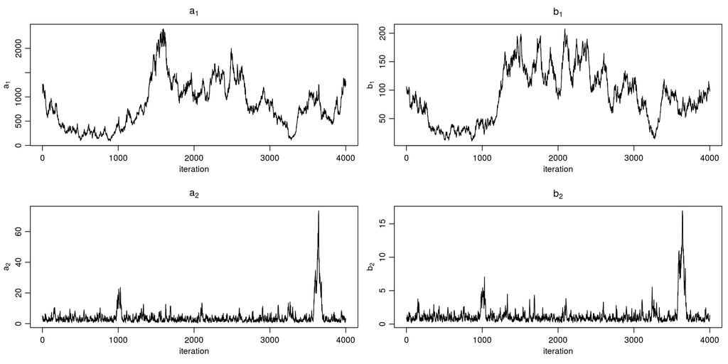

```r
makePlot(samplesSlice)
```

# Blocking parameters

Often a key factor that reduces MCMC performance is dependence between parameters that limits the ability of univariate samplers to move very far. A standard strategy is to sample correlated parameters in blocks. Unlike many other MCMC engines, NIMBLE makes it easy for users to choose what parameters to sample in blocks.

We’ll try that here for `a` and `b`.

```r
for(h in hypers) {
      littersConf$removeSamplers(h)
}
littersConf$addSampler(target = c('a[1]','b[1]'), type = 'RW_block',
                              control = list(adaptInterval = 100))
```

```
## Note: Assigning an RW_block sampler to nodes with very different scales can result in low MCMC efficiency.  If all nodes assigned to RW_block are not on a similar scale, we recommend providing an informed value for the "propCov" control list argument, or using the AFSS sampler instead.
```

```r
littersConf$addSampler(target = c('a[2]','b[2]'), type = 'RW_block',
                              control = list(adaptInterval = 100))
```

```
## Note: Assigning an RW_block sampler to nodes with very different scales can result in low MCMC efficiency.  If all nodes assigned to RW_block are not on a similar scale, we recommend providing an informed value for the "propCov" control list argument, or using the AFSS sampler instead.
```

```r
littersMCMC <- buildMCMC(littersConf)
cLittersMCMC <- compileNimble(littersMCMC, project = littersModel, resetFunctions = TRUE)
```

```
## compiling... this may take a minute. Use 'showCompilerOutput = TRUE' to see C++ compiler details.
```

```
## compilation finished.
```

```r
set.seed(1)
samplesBlock <- runMCMC(cLittersMCMC, niter = niter, nburnin = nburn,
             inits = littersInits, nchains = 1, samplesAsCodaMCMC = TRUE)
```

```
## running chain 1...
```

```
## |-------------|-------------|-------------|-------------|
## |-------------------------------------------------------|
```

```r
effectiveSize(samplesBlock)
```

```
##        a[1]        a[2]        b[1]        b[2]     p[1, 1]     p[2, 1]
##   25.435298    9.778970   25.536156   14.573394    6.029119  253.330555
##     p[1, 2]     p[2, 2]     p[1, 3]     p[2, 3]     p[1, 4]     p[2, 4]
##    5.482732  261.837997    5.970933  308.373136    6.976281  324.276958
##     p[1, 5]     p[2, 5]     p[1, 6]     p[2, 6]     p[1, 7]     p[2, 7]
##    6.691227 1296.554776    6.597861 1541.113776    7.987651 1445.644142
##     p[1, 8]     p[2, 8]     p[1, 9]     p[2, 9]    p[1, 10]    p[2, 10]
##    6.814357 1833.498057    5.999134 3039.220410    7.064754 1882.266752
##    p[1, 11]    p[2, 11]    p[1, 12]    p[2, 12]    p[1, 13]    p[2, 13]
##    6.769513 2724.651739    6.847884 1321.174959    6.907003  417.513991
##    p[1, 14]    p[2, 14]    p[1, 15]    p[2, 15]    p[1, 16]    p[2, 16]
##    8.171873  577.713040   11.705349  150.303751    9.619827   72.898799
```

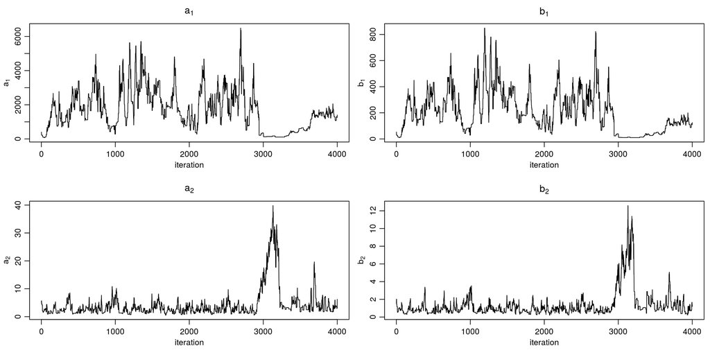

```r
makePlot(samplesBlock)
```

The block sampler seems to help some but hopefully we can do better. Often block sampling gives bigger improvements.

# Blocking the random effects too

But perhaps we should have blocked the hyperparameters with their dependent random effects. This is how one could do that, though `a`, `b`, and `p` are on very different scales, which may cause problems, particularly at the start of an adaptive sampler. As we see in the trace plots, this strategy is not working at all.

```r
littersConf$removeSamplers(c('a', 'b', 'p'))
group1nodes <- littersModel$getDependencies(c('a[1]', 'b[1]'), stochOnly = TRUE)
group2nodes <- littersModel$getDependencies(c('a[2]', 'b[2]'), stochOnly = TRUE)
group1nodes
```

```
##  [1] "a[1]"     "b[1]"     "p[1, 1]"  "p[1, 2]"  "p[1, 3]"  "p[1, 4]"
##  [7] "p[1, 5]"  "p[1, 6]"  "p[1, 7]"  "p[1, 8]"  "p[1, 9]"  "p[1, 10]"
## [13] "p[1, 11]" "p[1, 12]" "p[1, 13]" "p[1, 14]" "p[1, 15]" "p[1, 16]"
```

```r
propCov <- diag(c(.5, .5, rep(.01, 16)))
littersConf$addSampler(group1nodes, 'RW_block', control =
                       list(adaptInterval = 100, propCov = propCov))
```

```
## Note: Assigning an RW_block sampler to nodes with very different scales can result in low MCMC efficiency.  If all nodes assigned to RW_block are not on a similar scale, we recommend providing an informed value for the "propCov" control list argument, or using the AFSS sampler instead.
```

```r
littersConf$addSampler(group2nodes, 'RW_block', control =
                       list(adaptInterval = 100, propCov = propCov))
```

```
## Note: Assigning an RW_block sampler to nodes with very different scales can result in low MCMC efficiency.  If all nodes assigned to RW_block are not on a similar scale, we recommend providing an informed value for the "propCov" control list argument, or using the AFSS sampler instead.
```

```r
littersMCMC <- buildMCMC(littersConf)
cLittersMCMC <- compileNimble(littersMCMC, project = littersModel, resetFunctions = TRUE)
```

```
## compiling... this may take a minute. Use 'showCompilerOutput = TRUE' to see C++ compiler details.
```

```
## compilation finished.
```

```r
set.seed(1)
samplesSuperblock <- runMCMC(cLittersMCMC, niter = niter, nburnin = nburn,
                  inits = littersInits, nchains = 1, samplesAsCodaMCMC = TRUE)
```

```
## running chain 1...
```

```
## |-------------|-------------|-------------|-------------|
## |-------------------------------------------------------|
```

```r
effectiveSize(samplesSuperblock)
```

```
##      a[1]      a[2]      b[1]      b[2]   p[1, 1]   p[2, 1]   p[1, 2]
##  3.870116  9.689230  8.337090 11.193678 23.235640 42.547201 20.532846
##   p[2, 2]   p[1, 3]   p[2, 3]   p[1, 4]   p[2, 4]   p[1, 5]   p[2, 5]
## 43.562133  9.505130 48.569817 12.203838 38.347178  9.653021 14.516059
##   p[1, 6]   p[2, 6]   p[1, 7]   p[2, 7]   p[1, 8]   p[2, 8]   p[1, 9]
## 10.682164 18.042640 14.014543 44.019330  8.960318 40.886518 12.902910
##   p[2, 9]  p[1, 10]  p[2, 10]  p[1, 11]  p[2, 11]  p[1, 12]  p[2, 12]
## 45.177848 17.495385 31.456632  8.412508 13.178087 16.647042 21.997413
##  p[1, 13]  p[2, 13]  p[1, 14]  p[2, 14]  p[1, 15]  p[2, 15]  p[1, 16]
##  3.177107 15.460955 10.225952 16.926631 11.988963 17.912334 10.413544
##  p[2, 16]
## 22.931782
```

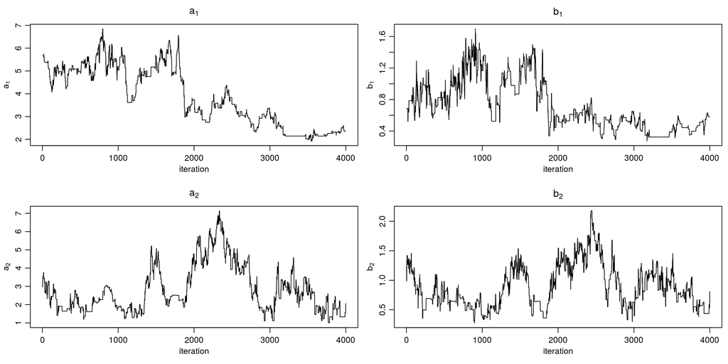

```r
makePlot(samplesSuperblock)
```

I suspect that more time for adaptation is needed (and perhaps better initialization of the proposal covariance).

# Implicitly integrating over the random effects: cross-level sampler

Note that in this model, one could analytically integrate over the random effects (necessarily so since we have conjugacy). In NIMBLE this is pretty easy to do using user-defined distributions (next module), though it requires some technical knowledge of working with distributions.

An easier alternative to analytically integrating over the random effects is to use a computational trick that mathematically achieves the same result.

That is NIMBLE’s *cross-level sampler*. Here’s what it does:

- do a blocked Metropolis random walk on one or more hyperparameters and then a conjugate update of the dependent nodes conditional on the proposed hyperparameters, accepting/rejecting everything together
- this amounts to a joint update of the hyperparameters and their dependent nodes
- equivalent to analytically integrating over the dependent nodes

```r
littersConf$removeSamplers(c('a', 'b', 'p'))
littersConf$addSampler(c('a[1]', 'b[1]'), 'crossLevel')
littersConf$addSampler(c('a[2]', 'b[2]'), 'crossLevel')

littersMCMC <- buildMCMC(littersConf)
cLittersMCMC <- compileNimble(littersMCMC, project = littersModel, resetFunctions = TRUE)
```

```
## compiling... this may take a minute. Use 'showCompilerOutput = TRUE' to see C++ compiler details.
```

```
## compilation finished.
```

```r
set.seed(1)
samplesCross <- runMCMC(cLittersMCMC, niter = niter, nburnin = nburn,
             inits = littersInits, nchains = 1, samplesAsCodaMCMC = TRUE)
```

```
## running chain 1...
```

```
## |-------------|-------------|-------------|-------------|
## |-------------------------------------------------------|
```

# Cross-level sampler results

```r
effectiveSize(samplesCross)
```

```
##     a[1]     a[2]     b[1]     b[2]  p[1, 1]  p[2, 1]  p[1, 2]  p[2, 2]
## 174.7002 123.7721 164.2023 161.8536 384.3497 501.6920 406.9321 675.6185
##  p[1, 3]  p[2, 3]  p[1, 4]  p[2, 4]  p[1, 5]  p[2, 5]  p[1, 6]  p[2, 6]
## 389.3645 526.6298 404.1256 610.6861 326.2830 597.5895 351.2667 663.2615
##  p[1, 7]  p[2, 7]  p[1, 8]  p[2, 8]  p[1, 9]  p[2, 9] p[1, 10] p[2, 10]
## 312.7498 726.8757 361.5656 502.1509 352.7005 675.2713 400.2829 620.3657
## p[1, 11] p[2, 11] p[1, 12] p[2, 12] p[1, 13] p[2, 13] p[1, 14] p[2, 14]
## 349.5235 723.0496 356.7016 603.1882 353.4078 593.5425 330.0875 656.0906
## p[1, 15] p[2, 15] p[1, 16] p[2, 16]
## 360.1016 622.1808 376.3246 332.3953
```

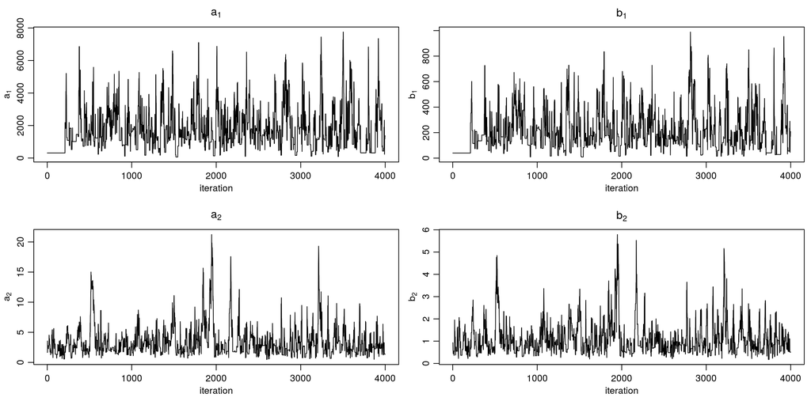

```r
makePlot(samplesCross)
```

Much better, though we’d still want to look into the lack of movement for `a[1], b[1]` in the initial non-burnin samples – this could probably be improved with better initialization of the top-level block sampler.

*Exercise*: try modifying the scale or propCov arguments to the cross-level sampler (see how we did this for the standard block sampler) and see if that eliminates the initial stickiness of the sampler.